# Projet **ITINERIS** Gestion des données de la recherche dans le contexte de la Science Ouverte

“*La science ouverte consiste à rendre accessible autant que possible et fermé autant que nécessaire*” (cnrs, n.d.). Ce document [R](https://www.r-project.org/) + [Markdown](https://rmarkdown.rstudio.com/) cherche à illustrer comment le projet d’ANR ‘ITINERIS’ (coord. Veronica Cicolani) entend gérer les données issues de sa recherche dans un contexte d’ouverture et de référencement de l’information scientifique (Science Ouverte), notamment en utilisant la grille de services de l’infrastructure [Huma-Num](https://www.huma-num.fr/).

Grille des services de la TGIR Huma-Num

service

logo

[Signaler](https://isidore.science/)

[Traiter](https://www.huma-num.fr/les-services-par-etapes/#traitement)

[Exposer](https://www.nakalona.fr/)

[Archiver](https://www.huma-num.fr/les-services-par-etapes/#preservation)

[Stocker](https://documentation.huma-num.fr/sharedocs-stockage/)

# Plan de gestion des données

La cohérence de la gestion des données scientifiques sera assurée par un développement intégré dans le conteneur d’application logicielles [GitLab d’Huma-Num](https://gitlab.huma-num.fr)

# Stockage

Dans le contexte de cette présentation les données sont herbergées sur l’ entrepôt de données (i.e., *data warehouse*, *repository*) GitHub accessible sur internet:

https://raw.githubusercontent.com/zoometh/golasecca/main/LOD

# Axes de recherche

[interactive chart not shown]

Description des *Work packages* (WP), *task* (T.) et des acteurs institutionnels

Partant d’une étude archéométrique des objets avec leur analyse physico-chimique et de surface (WP1, WP2), puis la remise de ces objets dans leur contexte historico-culturel de production, de circulation et d’utilisation (WP3)

## WP1

Ce programme de travail porte sur l’étude des états de surface et les analyses physico-chimiques

### Etats de surface

L’analyse de surface passera par une analyse macro- et micro-optique. Les données des études des états de surface seront renseignés selon les standards suivants:

Standards de l’analyse de surface (*surface texture*) pour la documentation technique et les méthodes du profil (ICs: instruments à contact, i.e. palpeur)

| ISO | description |  |
| --- | --- | --- |
| [1302:2002](https://www.iso.org/obp/ui/#iso:std:iso:1302:ed-4:v1:fr) | Production d’une documentation technique |  |
| [3274:1996](https://www.iso.org/fr/standard/1916.html) | Caractéristiques nominales des instruments à contact (palpeur) |  |
| [4287:1997](https://www.iso.org/fr/standard/10132.html) | Terminologie, description et paramètres |  |
| [4288:1996](https://www.iso.org/fr/standard/2096.html) | Règles et procédures de mesures |  |
| [5436-1:2000](https://www.iso.org/fr/standard/21978.html) | Étalonnage matériel et logiciel |  |
| [5436-2:2012](https://www.iso.org/fr/standard/61261.html) |  |  |
| [12085:1996](https://www.iso.org/fr/standard/20867.html) |  | Étalonnage motifs |
| [13565-1:1996](https://www.iso.org/fr/standard/22279.html) | Étalonnage des ICs, surfaces ayant des propriétés fonctionnelles différentes suivant les niveaux |  |
| [13565-2:1996](https://www.iso.org/fr/standard/22280.html) |  |  |
| [13565-3:1998](https://www.iso.org/fr/standard/26280.html) |  |  |

### Analyses physico-chimiques

Les analyses physico-chimiques permettront de caractériser les alliages cuivreux

Standards pour les analyses physico-chimiques

| ISO.TC | description |
| --- | --- |
| [ISO/TC 26](https://www.iso.org/fr/committee/47228.html) | Cuivre et alliages de cuivre |
| [17034:2016](https://www.iso.org/fr/standard/29357.html) | Analyses isotopiques |
| [10810:2019](https://www.iso.org/fr/standard/74286.html) | Spectroscopie Raman |
|  | Spectroscopie des rayon X |

## WP2

### Analyse 3D

Standards pour la gestion de la documentation 3D

| ISO | description |
| --- | --- |
| [14739-1:2014l](https://www.iso.org/fr/standard/54948.html) | Gestion de la documentation 3D (Lasergrammétrie, RTI) |

## WP3

### Base de données Web

La base de données web (T.5A) sera hébergée sur la grille du TGIR Huma-Num – l’instance française de la *Digital Research Infrastructure for the Arts and Humanities* (DARIAH-EU) – et librement accessible en ligne. La TGIR Huma-Num héberge déjà de nombreux projets numériques développés par le laboratoire AOROC. Cette structure de données va permettre l’implémentation d’une saisie mult-utilisateurs, la pérennité du stockage et faciliter l’interfaçage avec des données de recherche déjà implémentées par la coordinatrice du projet (VC), le *gazetteer* [Archeolocalis](https://archeolocalis.chronocarto.eu/?zlang=fr), la base de données [BaseFer](https://basefer.chronocarto.eu/).

Pour faciliter l’intéropérabilité des données, les données et leur métadonnées seront retranscrites à la volée par des routines informatiques écrites sous R:

Base de données

| description | format |
| --- | --- |
| Représenter/publier les données | JSON-LD |
|  | RDF |
| Décrire les données à partir de vocabulaires | XML-TEI |
| Historique des données | VoID |
|  | DCAT |
|  | PROV-O |
| Recherche de données | SPARQL |

Au sein de l’équipe, les documents de travail (*working papers*) seront échangés sur le [ShareDocs d’Human-Num](https://documentation.huma-num.fr/sharedocs-stockage/)

### Référencement FAIR

Basée sur l’ouverture de données (*open data*) décrites sémantiquement et des métadonnées (*metadata*), l’*Open Science* repose sur les principes du FAIR

| **F**acile à trouver |
| --- |
| **A**ccessible |
| **I**nteropérable |
| **R**éutilisable |

#### **F**acile à trouver

Repose sur l’attribution d’identifiants uniques (DOI) et un système standardisé de citations, comme les boutons “Citer” ou les liens qui affichent des les principaux formats de références biblographiques (.bib, .tex, etc.). Comme pour citer la page web [Golasecca-net](https://zoometh.github.io/golasecca) et l’article ayant servis à développer cette page:

https://raw.githubusercontent.com/zoometh/golasecca/main/bibliographie.bib

#### **A**ccessible

L’ouverture des données (*open data*) est à la base de la Science Ouverte, ces données seront accompagnées de métadonnées et recevront une certification

#### **I**ntéroperable

Les données seront intégrées à d’autres. Elles doivent donc être exprimées dans des formats ouverts et internationaux. C’est par exemple le cas du format WKT qui est le format standard, *human-readable*, pour la représentation des données géographiques.

Pour les données historico-culturelles (sites archéologiques, contexte stratigraphiques, typologie des objets, etc.), lors de la conception de la base de données, nous chercherons à aligner les champs et les valeurs sur le *Cultural Heritage Information-Conceptual Reference Model* ([CIDOC-CRM, ISO 21127](https://www.iso.org/standard/34424.html). Le CIDOC-CRM est un iso-standard pour la description et l’organisation de l’information liée au patrimoine archéologique et architectural

#### **R**éusable

La provenance, le nom du laboratoire, les méthodes et les équipements utilisés seront sourcés et sous license.

Exemples de licences utilisées dans le projet

| licences | description |
| --- | --- |
| ODbL | bases de données ouvertes |

Les données ouvertes seront connectées au web sémantique (*linked open data*, LOD). Ces données décrites comme des triples structurés sous la forme: sujet-prédicat-objet, au format *Resource Description Framework* (RDF) et enregistrées selon la syntaxe *JavaScript Object Notation for Linked Data* (JSON-LD).

Par exemple pour le site d’Uto-Kulm (n° 247) durant la phase [Golasecca IIAB-IIIA1](https://zoometh.github.io/golasecca/#Golasecca_IIAB-IIIA1):

```r
site <- "Uto-Kulm"
per <- "GIIAB_IIIA1_530_450"
urlfile<-'https://raw.github.com/zoometh/golasecca/master/LOD/data/data_temp.csv'
df <- read.csv(urlfile)
df.select <- df[df[ , "Lieu_dit"] == site & df[ , per] > 0, ]
df.per.count <- df.select %>% count(Objet)
df.per.count$Site <- site
kable(df.per.count,"html",
      row.names = F,
      caption = "Nombre des différents types d'objets pour
      le site d'Uto-Kulm au Golasecca IIAB-IIIA1") %>%
  collapse_rows() %>%
  kable_styling(full_width = FALSE,
                position = "center",
                font_size=12)
```

Nombre des différents types d’objets pour le site d’Uto-Kulm au Golasecca IIAB-IIIA1

| Objet | n | Site |
| --- | --- | --- |
| Ceramique grecque | 2 | Uto-Kulm |
| Parure Golasecca | 1 |  |

Où:

- **Site** = sujet
- **Objet** = prédicat
- **n** = objet

Le langage de programmation R, offre différents *packages* ([rdflib](https://cran.r-project.org/web/packages/rdflib/vignettes/rdf_intro.html), [jsonld](https://cran.r-project.org/web/packages/jsonld/index.html), etc.) permettant de formater les données de l’étude sous la forme de LOD:

```r
rdf <- rdf()
for (i in 1:nrow(df.per.count)){
  rdf %>%
    rdf_add(subject = paste0(base, df.per.count[i,"Site"]),
            predicate = paste0(base, df.per.count[i,"Objet"]),
            object = df.per.count[i,"n"])
}
rdf
```

```
## Total of 2 triples, stored in hashes
## -------------------------------
## <https://github.com/zoometh/golasecca/tree/main/Uto-Kulm> <https://github.com/zoometh/golasecca/tree/main/Ceramique grecque> "2"^^<http://www.w3.org/2001/XMLSchema#integer> .
## <https://github.com/zoometh/golasecca/tree/main/Uto-Kulm> <https://github.com/zoometh/golasecca/tree/main/Parure Golasecca> "1"^^<http://www.w3.org/2001/XMLSchema#integer> .
```

Le triple peut être sérialisé sous le format JSON-LD, actuellement le plus populaire pour décrire des données web et qui sera bientôt intégré par Google.

```r
json.name <- paste0(getwd(), site, "_", per,".json")
rdf_serialize(rdf, json.name, "jsonld")
```

Ce fichier peut ensuite être déposé sur GitHub :

https://raw.githubusercontent.com/zoometh/golasecca/main/LOD/Uto-Kulm_GIIAB_IIIA1.json

### Modélisation

#### Analyses de réseaux

L’analyse de réseaux (*network analysis*) est un formalisme largement utilisé, en même temps qu’une heuristique visuelle (*graph drawing*) pour la représentation des ensembles structurés. Elle sera employée à différentes échelle et selon différents paradigmes:

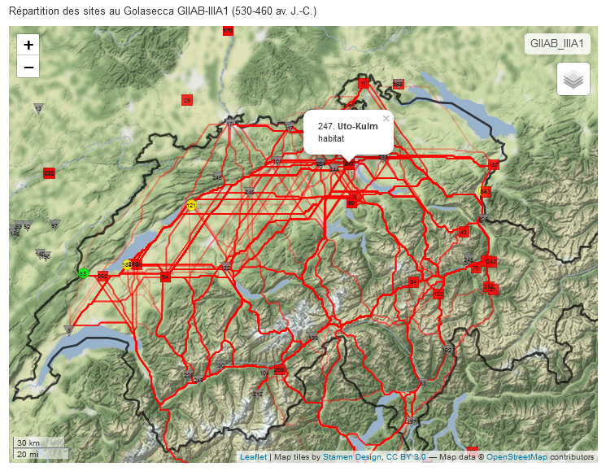

Exemple d’analyse de réseaux et de cartographie interactive, extrait de la page web [Golasecca-net](https://zoometh.github.io/golasecca/#Golasecca_IIAB-IIIA1)

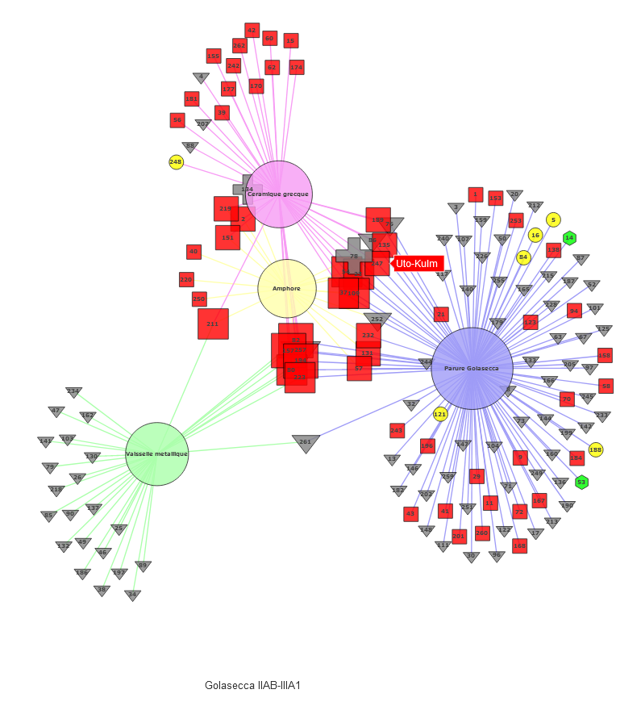

Exemple d’analyse de graphe, extrait de la page web [Golasecca-net](https://zoometh.github.io/golasecca/#Golasecca_IIAB-IIIA1)

#### Modélisation mathématique et spatiale

Les données de la modélisation mathématique et spatiale seront mises aux formats conventionnellement utilisés dans ces domaines.

Standards pour les analyses mathématiques et spatiales

| ISO | description |
| --- | --- |
| [80000-2:2019](https://www.iso.org/fr/standard/64973.html) | Modélisation mathématique |
| [19115:2003](https://www.iso.org/fr/standard/26020.html) | Information géographique |

cnrs. n.d. “Science Ouverte.” https://www.science-ouverte.cnrs.fr/.